# Data Visualization Project

Theo Kwanga @NYCDSA

27 Juni 2016

### Visualizing German Credit data using ggplot2 and dplyr

#### Dataset description

The German credit data donated by Prof Dr. Hoffmann in 1994 is freely downloadable from the UCI website Access data here. The dataset contains 1000 observations of bank customers credit details. For privacy reasons, the dataset had been anonymized before making it public. The dataset has the following 20 categorical and numeric attributes listed below with the “names” command after loading the required packages and the data from the csv file:

```r
library(ggplot2)
library(dplyr)
library(data.table)
library(magrittr)
German_Credit = read.csv("german_credit_New.csv", header = T)
German_Credit = tbl_df(German_Credit)
```

```r
names(German_Credit)
```

```
##  [1] "Account.Balance"
##  [2] "Credit_duration"
##  [3] "Payment.Status.of.Previous.Credit"
##  [4] "Purpose"
##  [5] "Credit.Amount"
##  [6] "Value.Savings.Stocks"
##  [7] "Length.of.current.employment"
##  [8] "Instalment.per.cent"
##  [9] "Sex...Marital.Status"
## [10] "Guarantors"
## [11] "Duration.in.Current.address"
## [12] "Most.valuable.available.asset"
## [13] "Age..years."
## [14] "Concurrent.Credits"
## [15] "Type.of.apartment"
## [16] "No.of.Credits.at.this.Bank"
## [17] "Occupation"
## [18] "No.of.dependents"
## [19] "Telephone"
## [20] "Foreign.Worker"
## [21] "X"
```

#### Data cleansing

The values of the attributes in the dataset are encoded with a code ranging from A11 to A202. These codes make the data visually incomprehensible therefore I had to decode some of the attribute values using the information provided in the dataset description. Variable renaming was not necessary since the names are mostly self explanatory.

```r
# Grouping the various ages into their decennial brackets.
German_Credit_New = German_Credit %>%
  mutate(Age..years. =
           ifelse(Age..years. <= 20, "under 20",
                  ifelse(Age..years. <= 29, "Twenties",
                         ifelse(Age..years. <= 39, "Thirties",
                                ifelse(Age..years. <= 49, "Forties",
                                       ifelse(Age..years. <= 59, "Fifties",
                                              ifelse(Age..years. <= 69, "Sixties", "Over Seventy")))))))
```

```r
# Renaming the length of employment codes.
German_Credit_New1 = German_Credit_New %>%
  mutate(Length.of.current.employment =
           ifelse(Length.of.current.employment == "A71", "Unemployed",
                  ifelse(Length.of.current.employment == "A72", "Less than 1 year",
                         ifelse(Length.of.current.employment == "A73", "Less than 4 year",
                                ifelse(Length.of.current.employment == "A74", "Less than 7 year", "Over 7 years")))))
```

```r
# Decoding the values for the type of appartment.
German_Credit_New2 = German_Credit_New1 %>%
  mutate(Type.of.apartment =
           ifelse(Type.of.apartment == "A151", "Rent",
                  ifelse(Type.of.apartment == "A152", "Own", "For free")))
```

```r
# The decoded purposes of the credits is given below.
German_Credit_New3 = German_Credit_New2 %>%
  mutate(Purpose =
           ifelse(Purpose == "A40", "New Car",
                  ifelse(Purpose == "A41", "Used Car",
                         ifelse(Purpose == "A42", "Furniture Or Equipment",
                                ifelse(Purpose == "A43", "Radio or Television",
                                       ifelse(Purpose == "A44","Domestic Appliances",
                                              ifelse(Purpose == "A45","Repairs",
                                                     ifelse(Purpose == "A46", "Education",
                                                            ifelse(Purpose == "A47", "Vacation",
                                                                   ifelse(Purpose == "A48","Retraining",
                                                                          ifelse(Purpose == "A49", "Business","Others")))))))))))
```

```r
# The professions have been decoded into four groups as shown below.
German_Credit_New4 = German_Credit_New3 %>%
  mutate(Occupation =
           ifelse(Occupation == "A171", "Unemployed/ unskilled",
                  ifelse(Occupation == "A172", "Unskilled",
                         ifelse(Occupation == "A173", "Skilled employee ", "Highly qualified employee"))))
```

```r
# decoding the marital status.
German_Credit_New5 = German_Credit_New4 %>%
  mutate(Sex...Marital.Status =
           ifelse(Sex...Marital.Status == "A91", "M_Divorced/separated",
                ifelse(Sex...Marital.Status == "A92", "F_Divorced/separated/married",
                    ifelse(Sex...Marital.Status == "A93", "M_Single",
                        ifelse(Sex...Marital.Status == "A94", "M_Married/widowed", "F_Single")))))
```

```r
sum(German_Credit$Credit.Amount) # Total credit amount in DM
```

```
## [1] 3271258
```

```r
mean(German_Credit$Credit.Amount) # Average credit amount in DM
```

```
## [1] 3271.258
```

```r
max(German_Credit$Credit.Amount) # Maximum credit amount in DM
```

```
## [1] 18424
```

```r
min(German_Credit$Credit.Amount) # Minimum credit amount in DM
```

```
## [1] 250
```

#### Data set visualization

The total credit amount given out to 1000 customers is 3271258 DM and the mean, max and min credit amounts are 3271.258 DM, 18424 DM and 250 DM respectively as shown in the summary and boxplot of the credit amounts below.

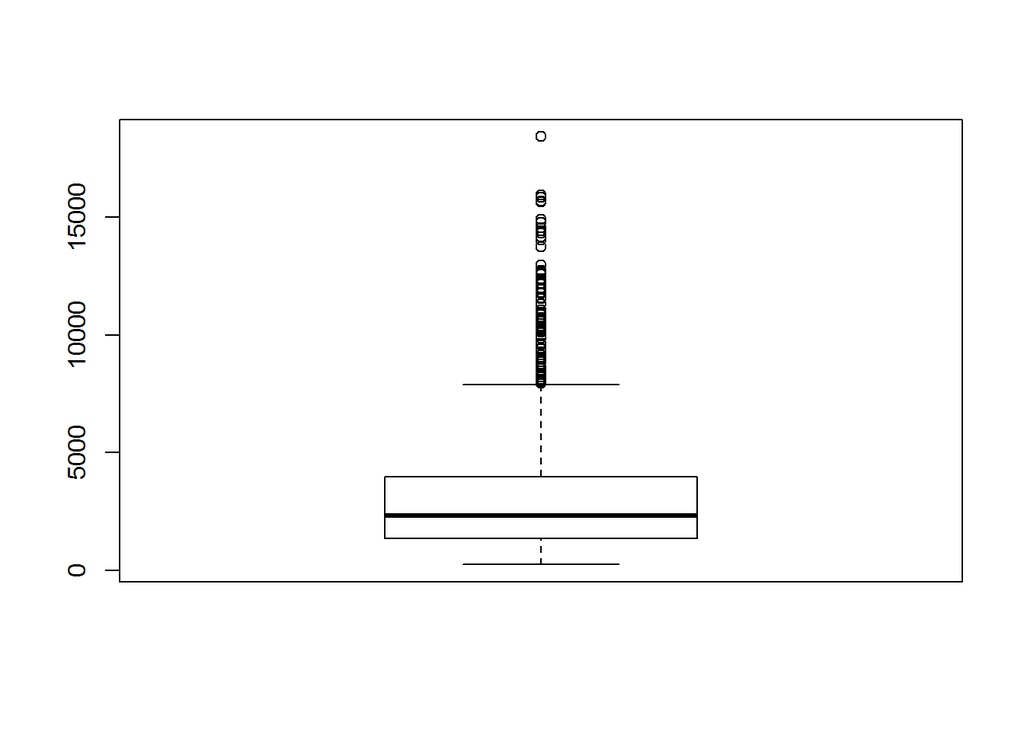

```r
boxplot(German_Credit$Credit.Amount) # show mean, max ..
```

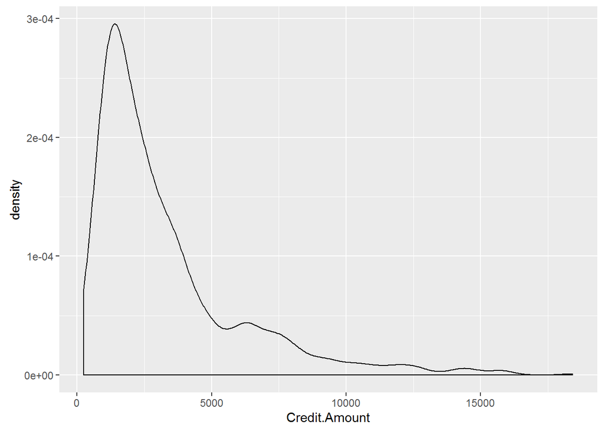

```r
ggplot(German_Credit, aes(x = Credit.Amount)) + geom_density()
```

A more informative distribution of the credit amounts is given by the histogram below showing the number of customers receiving a particular credit amount.

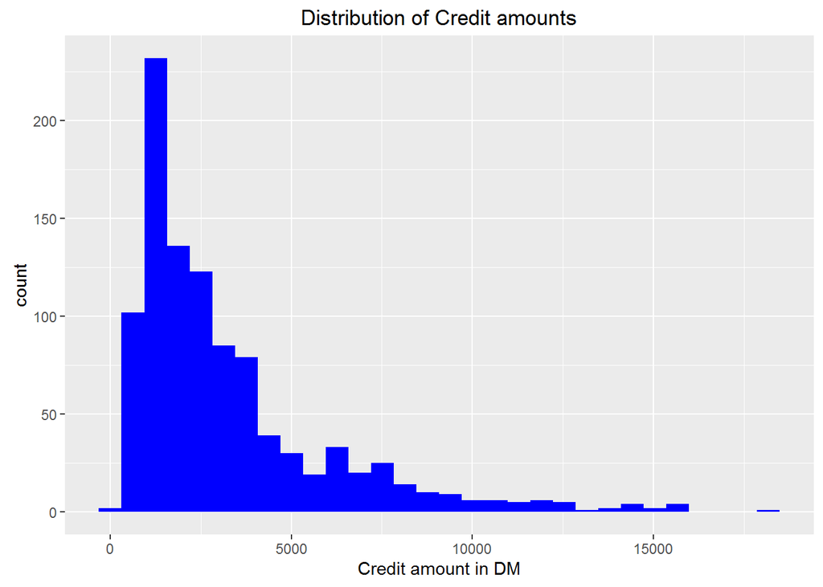

```r
ggplot(data=German_Credit_New5, aes(Credit.Amount)) + geom_histogram(fill="blue") +
  labs(title="Distribution of Credit amounts") + xlab("Credit amount in DM")
```

This also confirms that a high proportion of the credits are below 5000 DM as seen in the density plot above. The histogram of the credit duration below shows that most credits are given to customers for less than 24 months.

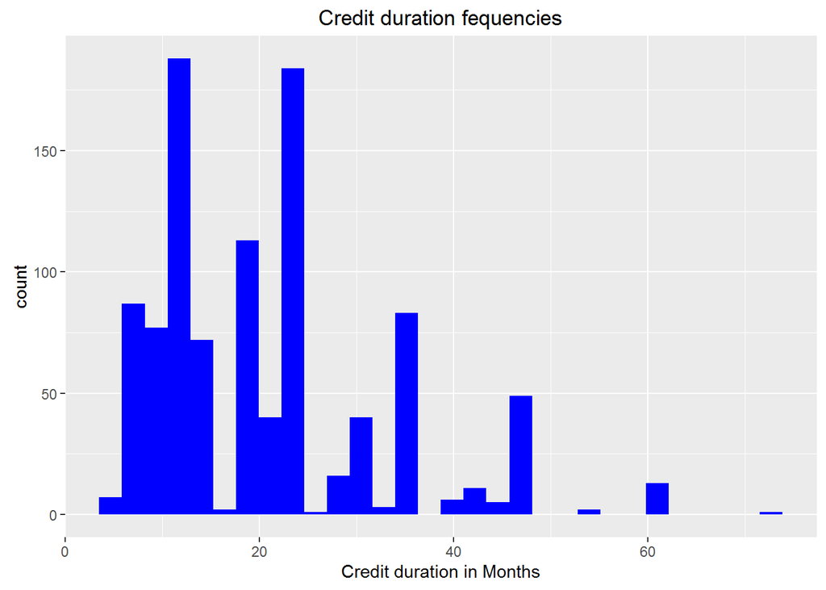

```r
ggplot(data=German_Credit_New4, aes(Credit_duration)) + geom_histogram(fill="blue") +
  labs(title="Credit duration fequencies") + xlab("Credit duration in Months")
```

The histogram of the ages below shows that less credits were given to customers who were above 40 years of age.

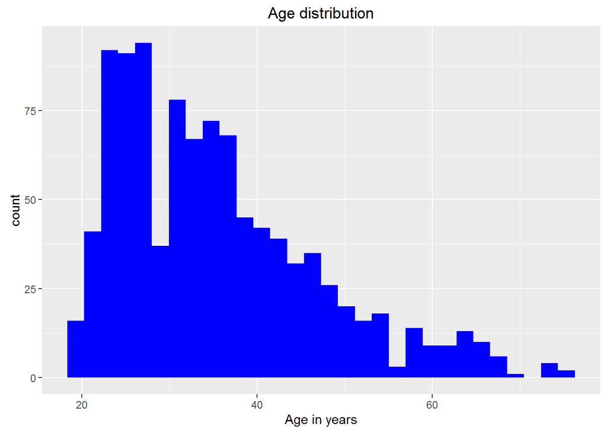

```r
ggplot(data=German_Credit, aes(Age..years.)) + geom_histogram(fill="blue") +
  labs(title="Age distribution") + xlab("Age in years")
```

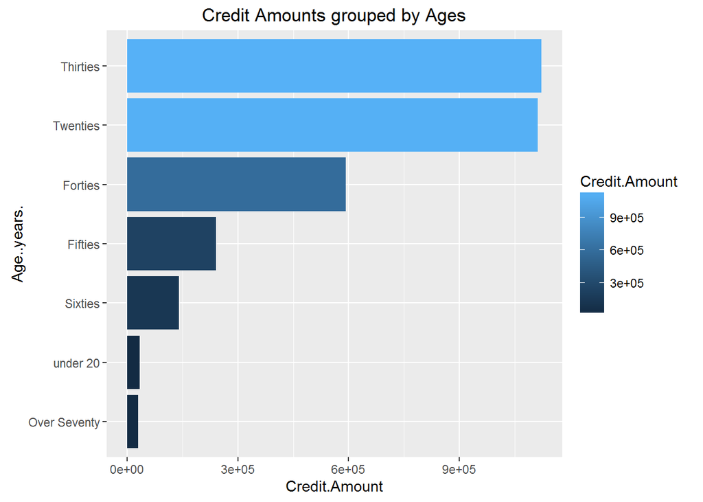

```r
By_Age..years. = German_Credit_New4 %>%
  group_by(Age..years.) %>% select(Age..years., Credit.Amount) %>%
  summarise_each(funs(sum))

By_Age..years.$Age..years. = factor(By_Age..years.$Age..years., levels = By_Age..years.$Age..years.[order(By_Age..years.$Credit.Amount)])

ggplot(By_Age..years., aes(x = Age..years., y = Credit.Amount, fill = Credit.Amount)) + geom_bar(stat = "identity") + coord_flip() +
  ggtitle("Credit Amounts grouped by Ages")
```

As shown in the bar chart above, Most credits are taken by customers between the ages of 20 and 40.

A grouping of the total credit amount according to the purpose is shown below.

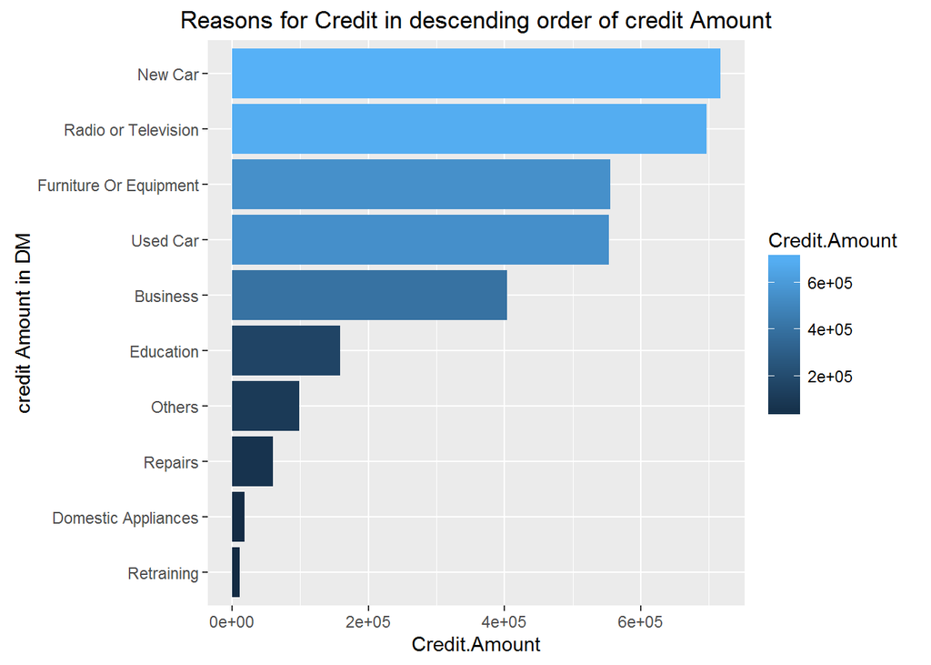

```r
By_Purpose = German_Credit_New4 %>%
  group_by(Purpose) %>% select(Purpose, Credit.Amount) %>%
  summarise_each(funs(sum))

By_Purpose$Purpose = factor(By_Purpose$Purpose, levels = By_Purpose$Purpose[order(By_Purpose$Credit.Amount)])

ggplot(By_Purpose, aes(x = Purpose, y = Credit.Amount, fill = Credit.Amount)) + geom_bar(stat = "identity") + coord_flip() +
ggtitle("Reasons for Credit in descending order of credit Amount") +
xlab("credit Amount in DM")
```

The credit amounts sorted according to the four occupational groups is shown below.

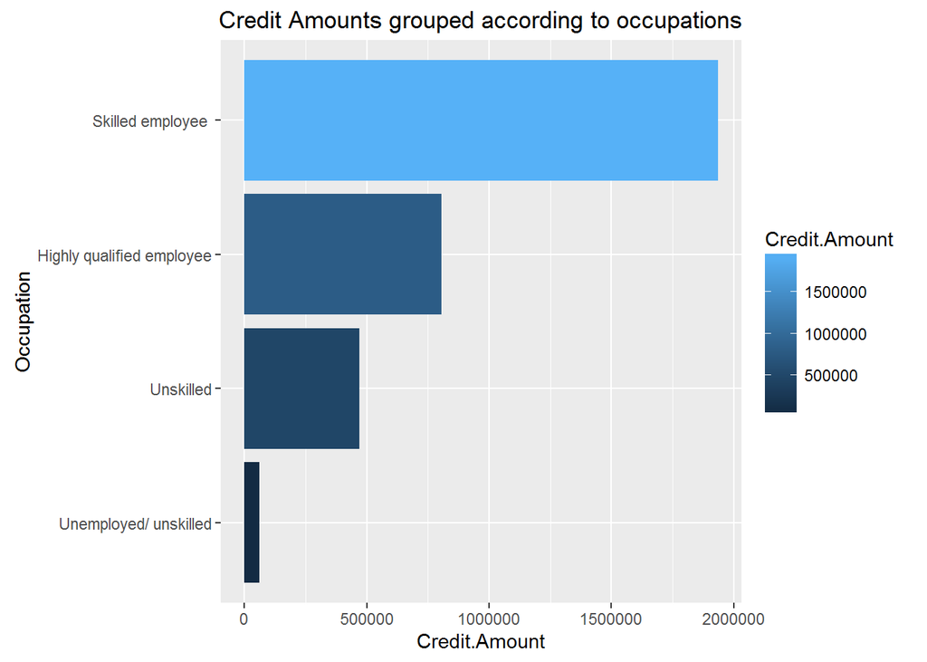

```r
By_Occupation = German_Credit_New4 %>%
  group_by(Occupation) %>% select(Occupation, Credit.Amount) %>%
  summarise_each(funs(sum))

By_Occupation$Occupation = factor(By_Occupation$Occupation, levels = By_Occupation$Occupation[order(By_Occupation$Credit.Amount)])

ggplot(By_Occupation, aes(x = Occupation, y = Credit.Amount, fill = Credit.Amount)) + geom_bar(stat = "identity") + coord_flip() +
  ggtitle("Credit Amounts grouped according to occupations")
```

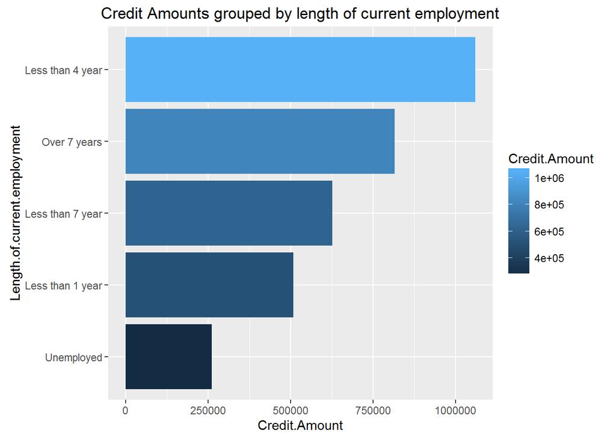

```r
By_Length.of.current.employment = German_Credit_New1 %>%
  group_by(Length.of.current.employment) %>% select(Length.of.current.employment, Credit.Amount) %>%
  summarise_each(funs(sum))

By_Length.of.current.employment$Length.of.current.employment = factor(By_Length.of.current.employment$Length.of.current.employment, levels = By_Length.of.current.employment$Length.of.current.employment[order(By_Length.of.current.employment$Credit.Amount)])

ggplot(By_Length.of.current.employment, aes(x = Length.of.current.employment, y = Credit.Amount, fill = Credit.Amount)) + geom_bar(stat = "identity") + coord_flip() +
  ggtitle("Credit Amounts grouped by length of current employment")
```

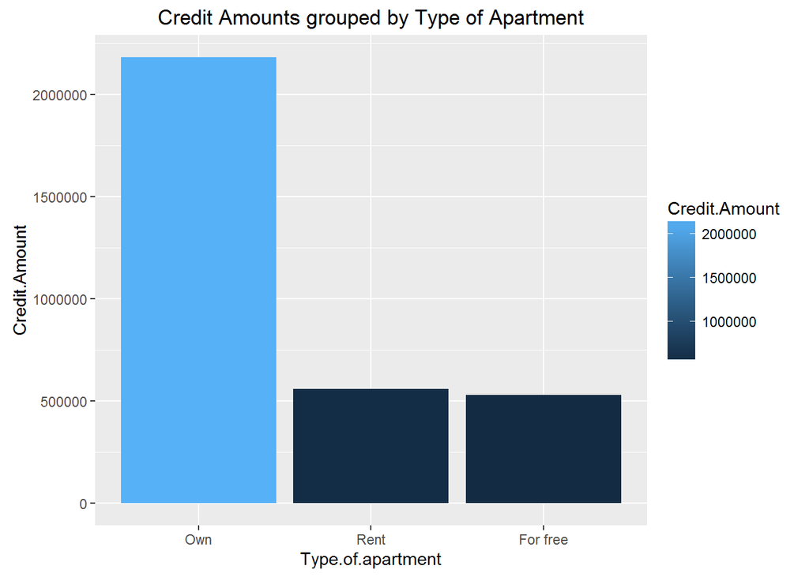

```r
By_Type.of.apartment = German_Credit_New2 %>%
  group_by(Type.of.apartment) %>% select(Type.of.apartment, Credit.Amount) %>%
  summarise_each(funs(sum))
By_Type.of.apartment$Type.of.apartment = factor(By_Type.of.apartment$Type.of.apartment, levels = By_Type.of.apartment$Type.of.apartment[order(desc(By_Type.of.apartment$Credit.Amount))])

ggplot(By_Type.of.apartment, aes(x = Type.of.apartment, y = Credit.Amount, fill = Credit.Amount)) + geom_bar(stat = "identity") + ggtitle("Credit Amounts grouped by Type of Apartment")
```

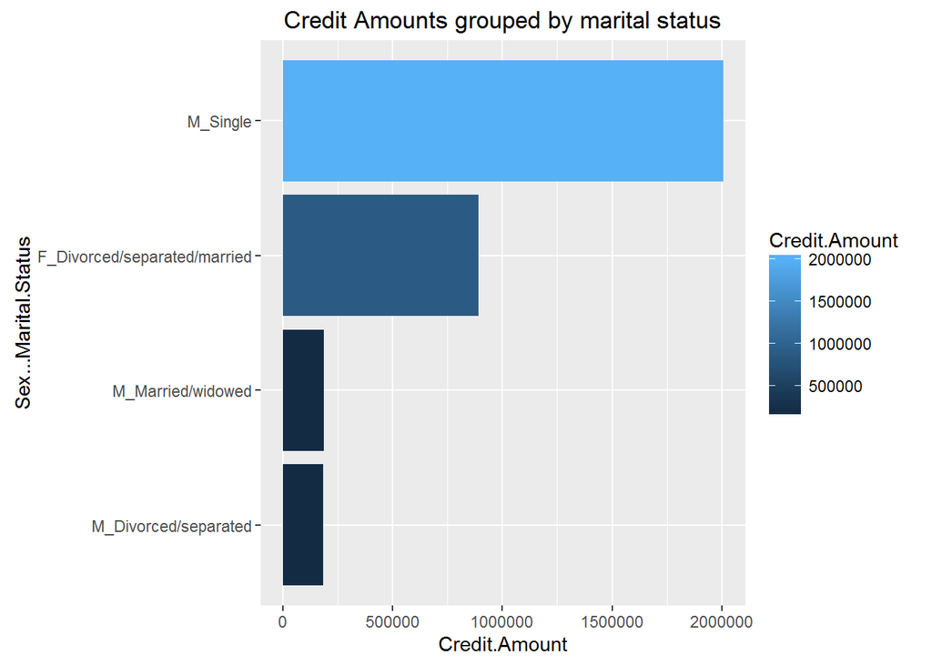

```r
By_Marital_Status = German_Credit_New5 %>%
  group_by(Sex...Marital.Status) %>% select(Sex...Marital.Status, Credit.Amount) %>%
  summarise_each(funs(sum))

By_Marital_Status$Sex...Marital.Status = factor(By_Marital_Status$Sex...Marital.Status, levels = By_Marital_Status$Sex...Marital.Status[order(By_Marital_Status$Credit.Amount)])

ggplot(By_Marital_Status, aes(x = Sex...Marital.Status, y = Credit.Amount, fill = Credit.Amount)) + geom_bar(stat = "identity") + coord_flip() +
  ggtitle("Credit Amounts grouped by marital status")
```

## Conclusions

A number of surprising observations come to light in the various charts above like:  
- The sum of credits taken for new cars and likewise for Radio/television are both greater that the combine amounts of credits taken for business, education and retraining.  
- New car and radio/television are responsible for almost half of all credits taken.